# Spatial Queries

02 June, 2026

To see more complete package documentation check out: https://pfrater.github.io/arcpullr/

ArcGIS REST API’s may be spatially queried using the get_layer_by_* family of functions. These functions require a spatial object of class `sf` (*i.e.* of the R package [sf: Simple Features for R](https://r-spatial.github.io/sf/)) and a [Spatial Relationship](https://help.arcgis.com/en/webapi/wpf/apiref/ESRI.ArcGIS.Client~ESRI.ArcGIS.Client.Tasks.SpatialRelationship.html) to be passed to the geometry and `sp_rel` arguments respectively.

The package contains five functions that can be used to perform spatial queries:

- `get_layer_by_line`
- `get_layer_by_point`
- `get_layer_by_polygon`
- `get_layer_by_multipoint`
- `get_layer_by_envelope`

## URL’s for examples

  **Example Source Data**

  ```r
  #WDNR Server
  server <- "https://dnrmaps.wi.gov/arcgis/rest/services/"
  server2 <- "https://dnrmaps.wi.gov/arcgis2/rest/services/"

  #River URL
  layer <- "TS_AGOL_STAGING_SERVICES/EN_AGOL_STAGING_SurfaceWater_WTM/MapServer/2"
  river_url <- paste0(server2,layer)

  #Country URL
  layer <- "DW_Map_Dynamic/EN_Basic_Basemap_WTM_Ext_Dynamic_L16/MapServer/3"
  county_url <- paste0(server,layer)

  #Trout URL
  layer <- "FM_Trout/FM_TROUT_HAB_SITES_WTM_Ext/MapServer/0"
  trout_url <- paste0(server,layer)

  #Watershed URL
  layer <- "WT_SWDV/WT_Federal_Hydrologic_Units_WTM_Ext/MapServer/0"
  watershed_url <- paste0(server,layer)

  #get layers for queries
  mke_river <- get_spatial_layer(
    river_url,
    where = "RIVER_SYS_NAME = 'Milwaukee River'"
  )

  trout_hab_project_pts <- get_spatial_layer(
    trout_url,
    where = "WATERBODYNAMECOMBINED = 'Sugar Creek' and FISCALYEAR = 2017"
  )

  trout_hab_project_pt <- trout_hab_project_pts[1, ]

  # get watershed layer for Cook Creek
  cook_creek_ws <- get_spatial_layer(
    watershed_url,
    where = "HUC12_NAME = 'Cook Creek'"
  )
  ```

## get_layer_by_line

  The `get_layer_by_line` function uses A LINSESTRING or MULTILINESTRING sf object to query an ArcGIS REST API. The below example uses a MULTILINESTRING sf object of the Milwaukee River to query the Wisconsin County polygon layer.

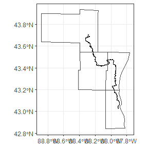

  ```r
  mke_river_counties <- get_layer_by_line(url = county_url, geometry = mke_river)
  plot_layer(mke_river, outline_poly = mke_river_counties)
  ```

## get_layer_by_point

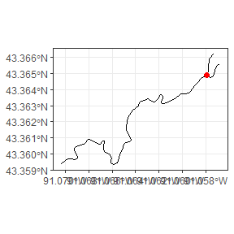

  ```r
  trout_stream <- get_layer_by_point(url = river_url, geometry = trout_hab_project_pt)
  plot_layer(trout_stream) +
    ggplot2::geom_sf(data = trout_hab_project_pt, color = "red", size = 2)
  ```

  `get_layer_by_point` can also handle multipoint objects. This example shows the same stream as above with a single point, but now with multiple restoration points.

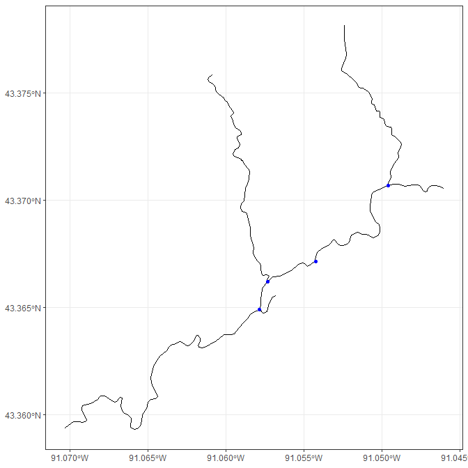

  ```r
  restored_streams <- get_layer_by_point(url = river_url, geometry = trout_hab_project_pts)
  plot_layer(restored_streams) +
    ggplot2::geom_sf(data = trout_hab_project_pts, color = "blue")
  ```

## get_layer_by_polygon

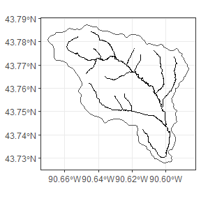

  ```r
  cook_creek_streams <- `get_layer_by_poly(river_url, cook_creek_ws)
  plot_layer(cook_creek_streams, cook_creek_ws)
  ```

## get_layer_by_envelope

  The `get_layer_by_envelope` function accepts any sf object to query an ArcGIS REST API using the sf objects bounding box. The below example shows how this is used to query WI’s Rivers ArcGIS REST API using a sf POLYGON object of a watershed for a small stream. Note how the results compare to when this same object is queried using the `get_layer_by_poly` function.

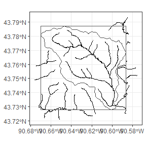

  ```r
  cook_creek_env <- get_layer_by_envelope(river_url, cook_creek_ws)

  # example of the envelope to visualize how it spatially queries
  example_env <- sf::st_as_sfc(sf::st_bbox(cook_creek_ws))

  plot_layer(cook_creek_env, cook_creek_ws) +
    ggplot2::geom_sf(data = example_env, fill = NA)
  ```

## Spatial Relationship

  The `sp_rel` argument can be used to define the spatial relationship between the two feature classes involved within a spatial query. The default spatial relationships for the `get_layer_by_poly` function is “contains”. All other functions default to “intersects”.

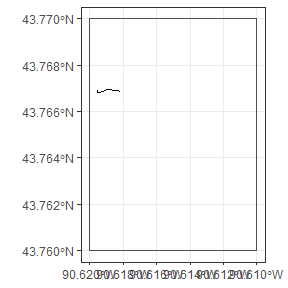

  ```r
  example_poly <- sf_polygon(
    c(-90.62, 43.76),
    c(-90.62, 43.77),
    c(-90.61, 43.77),
    c(-90.61, 43.76),
    c(-90.62, 43.76)
  )
  poly_streams_contains <- get_layer_by_poly(river_url, example_poly)
  plot_layer(poly_streams_contains, outline_poly = example_poly)
  ```

  Using “crosses” returns different records compared to the above example (i.e. this returns records when they cross the polygon border).

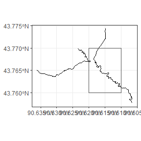

  ```r
  poly_streams_crosses <- get_layer_by_poly(river_url, example_poly, sp_rel = "crosses")
  plot_layer(poly_streams_crosses, outline_poly = example_poly)
  ```

### Lookup Tables

  The `sp_rel_lookup` data.frame explains the various types of spatial relationships available through ArcGIS REST APIs.

  |  | sp_rel | description |
  | --- | --- | --- |
  | 1 | esriSpatialRelContains | Part or all of a feature from feature class 1 is contained within a feature from feature class 2. |
  | 2 | esriSpatialRelCrosses | The feature from feature class 1 crosses a feature from feature class 2. |
  | 3 | esriSpatialRelEnvelopeIntersects | The envelope of feature class 1 intersects with the envelope of feature class 2. |
  | 4 | esriSpatialRelIndexIntersects | The envelope of the query feature class intersects the index entry for the target feature class. |
  | 5 | esriSpatialRelIntersects | Part of a feature from feature class 1 is contained in a feature from feature class 2. |
  | 6 | esriSpatialRelOverlaps | Features from feature class 1 overlap features in feature class 2. |
  | 7 | esriSpatialRelRelation | Indicates that a spatial relationship function will be used. |
  | 8 | esriSpatialRelTouches | The feature from feature class 1 touches the border of a feature from feature class 2. |
  | 9 | esriSpatialRelWithin | The feature from feature class 1 is completely enclosed by the feature from feature class 2. |

  The `sp_rel_valid` data.frame shows which spatial relationships are valid with different geometry types being queried and used to do spatial queries.

  |  | feature_class | query_feature_class | sp_rel |
  | --- | --- | --- | --- |
  | 1 | area | area | esriSpatialRelContains |
  | 2 | area | area | esriSpatialRelEnvelopeIntersects |
  | 3 | area | area | esriSpatialRelIndexIntersects |
  | 4 | area | area | esriSpatialRelIntersects |
  | 5 | area | area | esriSpatialRelOverlaps |
  | 6 | area | area | esriSpatialRelRelation |
  | 7 | area | envelope | esriSpatialRelContains |
  | 8 | area | envelope | esriSpatialRelEnvelopeIntersects |
  | 9 | area | envelope | esriSpatialRelIndexIntersects |
  | 10 | area | envelope | esriSpatialRelIntersects |

  [output cut: 95 more lines]

### The valid_sp_rel Function

  The `valid_sp_rel` function can be used to to see which spatial relation types are applicable to different geometries.

  ```r
  valid_sp_rel("line","line")
  ```

  ```
  #> [1] "esriSpatialRelCrosses"            "esriSpatialRelEnvelopeIntersects"
  #> [3] "esriSpatialRelIndexIntersects"    "esriSpatialRelIntersects"
  #> [5] "esriSpatialRelRelation"
  ```